# Estymacja modeli ANOVA

Aleksandra Węgrzyn

2024-11-20

## 1. Wprowadzenie

**Analiza wariancji (ANOVA)** to procedura statystyczna wykorzystywana do analizy różnic między grupami w kontekście jednego lub więcej czynników. Umożliwia badanie wpływu jednej lub kilku zmiennych niezależnych na zmienną zależną.

W ramach niniejszego projektu przeprowadzono estymacje trzech typów modeli ANOVA: wieloczynnikową, z powtarzanymi pomiarami oraz ANCOVA. Dane wykorzystane do estymacji modeli ANOVA zostały pozyskane z platformy [kaggle](https://www.kaggle.com/). Celem analizy jest zrozumienie wpływu poszczególnych czynników na zmienną zależną oraz identyfikacja potencjalnych interakcji zachodzących pomiędzy tymi czynnikami.

## 2. ANOVA wieloczynnikowa

**Anova wieloczynnikowa** umożliwia zbadanie łącznego wpływu różnych czynników na zmienną zależną. W niniejszej analizie wykorzystano zestaw danych, który zawiera wyniki wydajności 128 pracowników z uwzględnieniem stosownych narzędzi komunikacyjnych oraz środowiska pracy. Celem analizy jest zbadanie, czy rodzaj środowiska pracy oraz wykorzystywane narzędzie komunikacyjne mają istotny wpływ na wydajność pracownika.

Charakterystyka zmiennych:

- **`ProductivityScore`**: wynik wydajności pracownika [%]
- **`WorkSetting`**: środowisko pracy, przyjmujące trzy poziomy:
  - `Hybrid` - praca w trybie hybrydowym tzn. połączenie pracy w trybie zdalnym oraz stacjonarnym
  - `Home office` - praca zdalna
  - `Coworking space` - praca stacjonarna, w środowisku korporacyjnym
- **`CommunicationTool`**: narzędzie komunikacyjne używane przez pracownika, przyjmuje trzy poziomy:
  - `Zoom` - platforma videokonferencyjna
  - `Email` - tradycyjna komunikacja mailowa
  - `Slack` - narzędzie do komunikacji zespołowej

| WorkSetting | CommunicationTool | ProductivityScore |
| --- | --- | --- |
| Hybrid | Zoom | 93.08691 |
| Coworking space | Zoom | 98.87113 |
| Hybrid | Email | 81.42055 |
| Hybrid | Slack | 80.34142 |
| Home office | Email | 64.21400 |
| Hybrid | Slack | 59.74954 |
| Coworking space | Slack | 63.76900 |
| Hybrid | Email | 71.20824 |
| Hybrid | Slack | 72.64783 |
| Home office | Email | 59.14369 |
| Home office | Zoom | 44.01411 |
| Home office | Zoom | 78.88223 |
| Home office | Slack | 73.59931 |
| Hybrid | Zoom | 80.21687 |
| Coworking space | Email | 79.88170 |
| Home office | Slack | 66.38245 |
| Home office | Slack | 62.46119 |
| Home office | Email | 82.65936 |
| Home office | Email | 86.51437 |
| Home office | Slack | 97.05930 |
| Home office | Email | 63.61098 |
| Coworking space | Zoom | 61.94037 |
| Coworking space | Email | 90.69393 |
| Hybrid | Slack | 99.59411 |
| Home office | Slack | 82.37369 |
| Hybrid | Email | 86.50206 |
| Hybrid | Slack | 90.12739 |
| Home office | Zoom | 70.26364 |
| Coworking space | Slack | 77.27291 |
| Home office | Zoom | 65.00123 |

[output cut: 98 more lines]

### 2.1. Wstępna analiza danych

Przed przystąpieniem do głównej części analizy zbadano strukturę rozważanych danych oraz występowanie potencjalnych wartości brakujących. W przypadku stwierdzenia wystąpienia nieprawidłowości wprowadzono stosowne modyfikacje. Następnie wygenerowano wykresy pudełkowe, które posłużyły do oceny obecności obserwacji odstających w zbiorze danych. Wspomniane wizualizacje zostały zamieszczone poniżej.

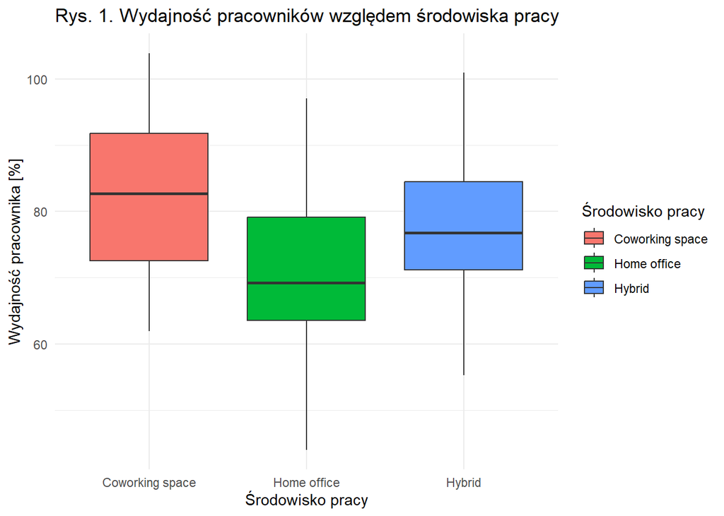

Na podstawie powyższej wizualizacji można stwierdzić, iż w przypadku czynnika określającego rodzaj środowiska pracy nie obserwuje się występowania wartości odstających.

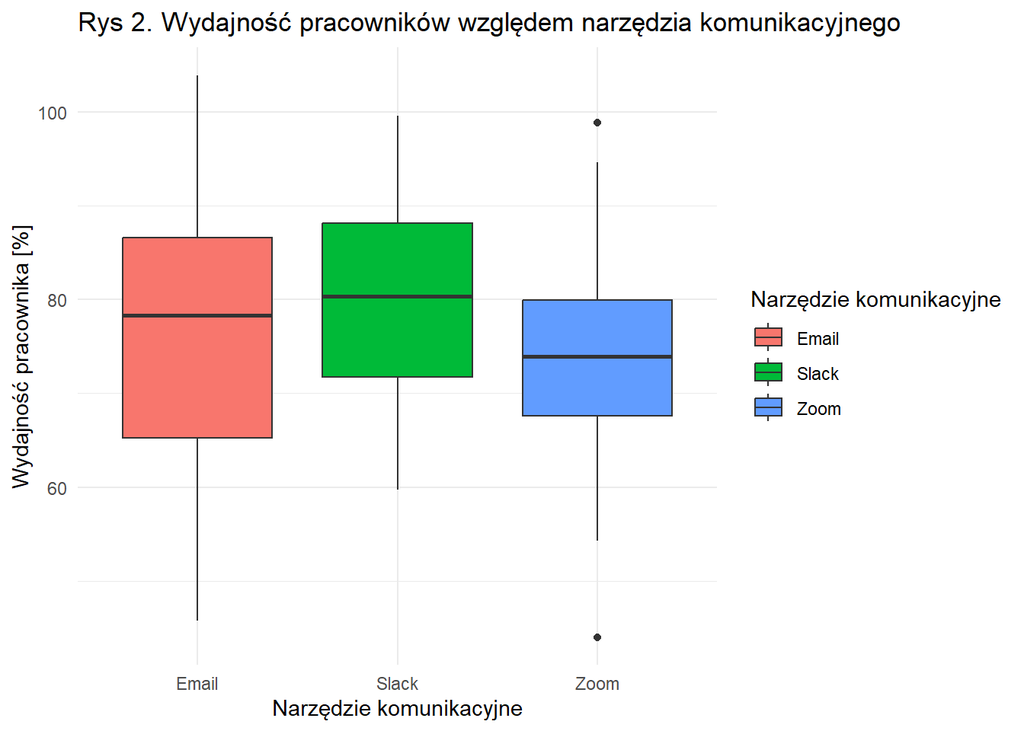

```
##   CommunicationTool ProductivityScore is.outlier is.extreme
## 1              Zoom          98.87113       TRUE      FALSE
## 2              Zoom          44.01411       TRUE      FALSE
```

Dla czynnika opisującego wykorzystywane narzędzie komunikacyjne zaobserwowano występowanie obserwacji odstających dla jednego z poziomów. W celu zredukowania wpływu wartości skrajnych na wyniki analizy, zdecydowano się na przeprowadzenie winsoryzacji tj. zastąpieniu wartości odstających długością dolnego oraz górnego wąsa obliczanymi według wzorów: $\small {Q_1} - 1,5 \cdot {(Q_3 - Q_1)}$ dla obserwacji odstających z dołu oraz $\small {Q_3} + 1,5 \cdot {(Q_3 - Q_1)}$ dla górnych wartości nietypowych. Statystyki opisowe dla rozważanych zmiennych po dokonaniu winsoryzacji przedstawiono poniżej.

```
##           WorkSetting CommunicationTool ProductivityScore
##  Coworking space:43   Email:44          Min.   : 45.73
##  Home office    :44   Slack:41          1st Qu.: 67.12
##  Hybrid         :41   Zoom :43          Median : 76.20
##                                         Mean   : 76.83
##                                         3rd Qu.: 85.11
##                                         Max.   :103.92
```

```
## 'data.frame':    128 obs. of  3 variables:
##  $ WorkSetting      : Factor w/ 3 levels "Coworking space",..: 3 1 3 3 2 3 1 3 3 2 ...
##  $ CommunicationTool: Factor w/ 3 levels "Email","Slack",..: 3 3 1 2 1 2 2 1 2 1 ...
##  $ ProductivityScore: num  93.1 98.4 81.4 80.3 64.2 ...
```

Jak można zauważyć, grupy nie są równoliczne, co będzie wymagało uwzględnienia w późniejszych etapach analizy.

Celem lepszego zrozumienia zależności między środowiskiem pracy oraz narzędziem komunikacyjnym na ocenę wydajności pracy pracowników, wyznaczono średnią arytmetyczną wydajności dla każdej grupy w kontekście rozważanych czynników. Uzyskane wartości stanowiły punkt wyjścia do wieloczynnikowej analizy wariancji, a także pozwoliły na sformułowanie wstępnych wniosków na temat analizowanych danych.

Tabela 1. Średnia wydajność pracowników w zależności od rodzaju środowiska pracy

| Środowisko pracy | Średnia wydajność |
| --- | --- |
| Hybrid | 77.21493 |
| Home Office | 70.67715 |
| Coworking Space | 82.75999 |

Wyniki zamieszczone w tabeli 1 wskazują na to, że praca stacjonarna w wspólnej przestrzeni roboczej (`Coworking Space`) sprzyja wyższej produktywności pracowników. Z kolei spośród analizowanych środowisk pracy najniższą średnią wydajność można zaobserwować dla pracowników pracujących z domu (`Home Office`).

Tabela 2. Średnia wydajność pracowników w zależności od wykorzystywanego narzędzia komunikacji

| Narzędzie komunikacyjne | Średnia wydajność |
| --- | --- |
| Zoom | 73.95269 |
| Slack | 79.63387 |
| Email | 77.03028 |

Powyższe wyniki wskazują na to, iż stosowanie przez pracowników narzędzia umożliwiającego komunikację zespołową (`Slack`) ma średnio najkorzystniejszy wpływ na ich wydajność pracy. Z kolei korzystanie z narzędzia do videokonferencji (`Zoom`) wydaje się mieć najmniej pozytywny wpływ na produktywność pracowników.

### 2.2. Badanie istnienia efektu interakcji

Przeprowadzenie wieloczynnikowej analizy wariancji rozpoczyna się od określenia, czy dla danych występuje statystycznie istotny efekt interakcji. Wstępną ocenę obecności wspomnianego zjawiska określono na podstawie wykresu interakcji dla narzędzia komunikacyjnego oraz rodzaju środowiska pracy. W celu ułatwienia interpretacji zdecydowano się na wykonanie dwóch wykresów interakcji, w których zmienne jakościowe przedstawiono zamiennie - raz na osi odciętych, a raz jako parametr reprezentowany przez linie. Pozwoliło to na bardziej przejrzystą ocenę interakcji między analizowanymi czynnikami.

[figure not shown]

Na powyższych wykresach interakcji można zaobserwować znaczne odstępstwo od równoległości narysowanych krzywych. Dodatkowo w przypadku pierwszego wykresu krzywe łączące odpowiednie średnie przecinają się, co sugeruje możliwość występowania istotnego efektu interakcji. Chcąc zweryfikować te przypuszczenia, przeprowadzono test ilorazu wiarygodności porównujacy model z interakcją z modelem bez interakcji. Przyjęto poziom istotności **$\alpha$ = 5%**.

Hipotezy dla testu mają postać:

$$\small{H}_0: \beta_3 = 0 \\
\small{H}_1: \beta_3 \neq 0$$
gdzie $\small \beta_3$ to parametr przy zmiennej interakcji, który reprezentuje połączenie dwóch czynników.

```r
model_without_I <- lm(ProductivityScore ~ CommunicationTool+WorkSetting,
                       data = productivity_score)
model_with_I <- lm(ProductivityScore ~ CommunicationTool*WorkSetting,
                    data = productivity_score)
print(anova(model_without_I, model_with_I))
```

```
## Analysis of Variance Table
##
## Model 1: ProductivityScore ~ CommunicationTool + WorkSetting
## Model 2: ProductivityScore ~ CommunicationTool * WorkSetting
##   Res.Df   RSS Df Sum of Sq      F Pr(>F)
## 1    123 15202
## 2    119 14348  4    855.01 1.7729 0.1388
```

Na podstawie uzyskanych wyników nie stwierdzono występowania statystycznie istotnej interakcji pomiędzy narzędziem komunikacyjnym a rodzajem środowiska pracy w kontekście wydajności pracy pracowników. Oznacza to, że wpływ obu czynników należy traktować jako niezależny, gdyż uwzględnienie interakcji między czynnikami nie przynosi znaczącej poprawy dla modelu.

Rozbieżność pomiędzy wynikami uzyskanymi na podstawie analizy wykresu interakcji a rezultatami testu statystycznego może wynikać z występowania bardzo słabej zależności pomiędzy badanymi czynnikami, co skutkuje jej niewykrywalnością przy zastosowaniu testu statystycznego.

### 2.3. Weryfikacja założeń

W celu prawidłowego przeprowadzenia dwuczynnikowej analizy wariancji, kluczowe jest upewnienie się, że spełnione zostały odpowiednie założenia. Dla rozważanych testów statystycznych przyjęto poziom istotności **$\alpha$ = 5%**.

#### 2.3.1. Niezależność obserwacji

Aby sprawdzić założenie o niezależności obserwacji przeprowadzono test $\small \chi2$, dla którego weryfikowane hipotezy mają postać:

$$\begin{align*}
\small{H}_0: & \small \text { zmienne są niezależne} \\
\small{H}_1: & \small \text{ zmienne są zależne}
\end{align*}$$

```r
contingency_table <- table(productivity_score$CommunicationTool, productivity_score$WorkSetting)

chi_square_result <- chisq.test(contingency_table)
cat("P-value: ", chi_square_result$p.value)
```

```
## P-value:  0.999879
```

Przy poziomie istotności $\alpha$ = 0.05, uzyskana wartość p wynosi 0.999879, co wskazuje na brak podstaw do odrzucenia hipotezy zerowej. Można zatem stwierdzić, że nie ma zależności pomiędzy zmiennymi narzędzie komunikacyjne oraz rodzaj środowiska pracy.

#### 2.3.2. Normalność w podgrupach

W celu zbadania normalności rozkładu zmiennej zależnej w podgrupach wyznaczonych poprzez poziomy badanych czynników przeprowadzono test Shapiro-Wilka. Układ hipotez dla wspomnianego testu jest następujący:

$$\begin{align*}
\small{H}_0: & \small \text { dane mają rozkład normalny} \\
\small{H}_1: & \small \text{ dane nie mają rozkładu normalnego}
\end{align*}$$

```r
tool_norm <- productivity_score %>%
  group_by(CommunicationTool) %>%
  shapiro_test(ProductivityScore)  %>%
  ungroup()
print(tool_norm)
```

```
## # A tibble: 3 × 4
##   CommunicationTool variable          statistic     p
##   <fct>             <chr>                 <dbl> <dbl>
## 1 Email             ProductivityScore     0.979 0.577
## 2 Slack             ProductivityScore     0.968 0.292
## 3 Zoom              ProductivityScore     0.984 0.810
```

```r
setting_norm <- productivity_score %>%
  group_by(WorkSetting) %>%
  shapiro_test(ProductivityScore)  %>%
  ungroup()
print(setting_norm)
```

```
## # A tibble: 3 × 4
##   WorkSetting     variable          statistic      p
##   <fct>           <chr>                 <dbl>  <dbl>
## 1 Coworking space ProductivityScore     0.955 0.0923
## 2 Home office     ProductivityScore     0.987 0.890
## 3 Hybrid          ProductivityScore     0.986 0.889
```

Na poziomie istotności 0.05 nie ma podstaw do odrzucenia hipotezy zerowej. Oznacza to, że dane mają rozkład normalny.

#### 2.3.3. Jednorodność wariancji w podgrupach

Kolejnym krokiem jest weryfikacja założenia o jednorodności wariancji w podgrupach. Ze względu na różną liczebność podgrup skorzystano w tym celu z testu Bartletta. Jednym z istotnych ograniczeń wspomnianego testu jest jego wrażliwość na odstępstwa od normalności rozkładu danych. W kontekście analizowanych danych, założenie o normalności zostało formalnie zweryfikowane przy pomocy testu Shapiro - Wilka, co umożliwia bezproblemowe zastosowanie tego testu w niniejszym przypadku.

$$\begin{align*}
\small{H}_0: & \small \quad \sigma_{1}^2=\sigma_{2}^2= \ ...\
=\sigma_{k}^2 \\
\small{H}_1: & \small \quad \sigma_{i}^2 \neq \sigma_{j}^2
\hspace{1.5em} dla \ pewnych \ \ \ i \neq j \\
\end{align*}$$

```r
bartlett.test(ProductivityScore ~ CommunicationTool, data = productivity_score)
```

```
##
##  Bartlett test of homogeneity of variances
##
## data:  ProductivityScore by CommunicationTool
## Bartlett's K-squared = 4.2017, df = 2, p-value = 0.1224
```

```r
bartlett.test(ProductivityScore ~ WorkSetting, data = productivity_score)
```

```
##
##  Bartlett test of homogeneity of variances
##
## data:  ProductivityScore by WorkSetting
## Bartlett's K-squared = 0.3201, df = 2, p-value = 0.8521
```

Dla ustalonego poziomu istotności $\alpha$, nie ma podstaw do odrzucenia hipotezy zerowej. Oznacza to, że założenie o jednorodności wariancji w podgrupach jest spełnione.

### 2.4. ANOVA

Do przeprowadzenia dwuczynnikowej analizy wariancji wykorzystano model addytywny, co było uzasadnione występowaniem nieistotnej statystycznie interakcji pomiędzy badanymi czynnikami. W związku z tym skupiono się na interpretacji efektów głównych każdego czynnika z osobna. W ramach analizy weryfikowano hipotezy:

$$\begin{align*}
\small H_0: m_{A1} = m_{A2} = \ldots = m_{Ak} \hspace{5.5em}
\small H_1: m_{A i} \neq m_{A j} \hspace{1.5em} dla \ pewnych \ \ \ i
\neq j \\
\small H_0: m_{B1} = m_{B2} = \ldots = m_{Bk} \hspace{5.5em}
\small H_1: m_{B i} \neq m_{B j} \hspace{1.5em} dla \ pewnych \ \ \ i
\neq j
\end{align*}$$

```r
model <- aov(ProductivityScore ~ CommunicationTool + WorkSetting,
             data = productivity_score)
summary(model)
```

```
##                    Df Sum Sq Mean Sq F value   Pr(>F)
## CommunicationTool   2    680   340.0   2.751   0.0678 .
## WorkSetting         2   3151  1575.4  12.746 9.32e-06 ***
## Residuals         123  15203   123.6
## ---
## Signif. codes:  0 '***' 0.001 '**' 0.01 '*' 0.05 '.' 0.1 ' ' 1
```

Na podstawie powyższych wyników dwuczynnikowej analizy wariancji można wyciągnąć następujące wnioski:

- wartość p dla zmiennej **`CommunicationTool`** jest wyższa od ustalonego poziomu istotności, co wskazuje, że stosowane narzędzie komunikacyjne nie wykazuje statystycznie istotnego wpływu na wyniki wydajności pracowników.
- wartość p dla zmiennej **`WorkSetting`** jest znacznie mniejsza od przyjętego poziomu istotności, zatem hipoteza zerowa zostaje odrzucona na rzecz hipotezy alternatywnej. Oznacza to, że istnieją istotne statystycznie różnice w wynikach wydajności pracowników w zależności od rodzaju środowiska pracy.

### 2.5. Analiza post-hoc

Chociaż ANOVA umożliwia ocenę różnic pomiędzy średnimi w grupach, nie wskazuje, które z nich są odpowiedzialne za zaobserwowane różnice. W związku z powyższym, gdy wyniki analizy wariancji wskazują na istotne statystycznie różnice między średnimi, kolejnym krokiem jest przeprowadzenie analizy post-hoc. Testy post-hoc, znane również jako testy wielokrotnych porównań, służą do dokładnego określenia, które pary grup różnią się istotnie od siebie.

Istotne statystycznie różnice między średnimi stwierdzono jedynie w przypadku jednego z rozważanych czynników, co uzasadnia przeprowadzenie testu post-hoc wyłącznie dla zmiennej określającej rodzaj środowiska pracy. Ze względu na różne liczebności grup do porównania parami średnich wartości zastosowano test Tuckeya. Weryfikacji poddano następujący zestaw hipotez:

$$\begin{align*}
\small H_0: m_{i} = m_{j} \hspace{3.5em} dla \ \ i \neq j \\
\small H_1: m_{i} \neq m_{j} \hspace{3.5em} dla \ \ i \neq j \\
\end{align*}$$

```r
TukeyHSD(model, "WorkSetting")
```

```
##   Tukey multiple comparisons of means
##     95% family-wise confidence level
##
## Fit: aov(formula = ProductivityScore ~ CommunicationTool + WorkSetting, data = productivity_score)
##
## $WorkSetting
##                                   diff         lwr        upr     p adj
## Home office-Coworking space -12.016408 -17.6722406 -6.3605755 0.0000048
## Hybrid-Coworking space       -5.474029 -11.2312247  0.2831661 0.0660734
## Hybrid-Home office            6.542379   0.8172049 12.2675526 0.0207947
```

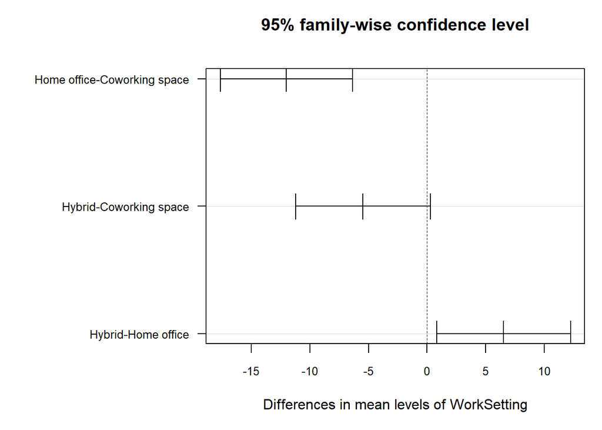

```r
par(mar = c(5, 12, 4, 1))
plot(TukeyHSD(model, "WorkSetting"), cex.axis = 0.8, las = 1)
```

Przeprowadzone testy post-hoc pozwalają stwierdzić, że różnica średnich wyników wydajności między pracownikami pracującymi hybrydowo a tymi, którzy pracują w przestrzeni coworkingowej wynosi -5.47, jednakże na podstawie wartości prawdopodobieństwa testowego nie została ona uznana za statystycznie istotną. Różnice dla pozostałych kombinacji poziomów rodzaju środowiska pracy zostały uznane za istotne statystycznie.

Dodatkowo wyniki testu zostały potwierdzone za pomocą wykresu przedziałów ufności dla trzech poziomów zmiennej **`WorkSetting`**. Tylko w przypadku kombinacji pracy hybrydowej oraz przestrzeni coworkingowej przedział ufności obejmuje zero, co wskazuje na brak istotnej różnicy między średnimi wynikami wydajności na poziomie istotności 5%. Dla pozostałych porównań przedziały ufności nie zawierają zera, co potwierdza występowanie istotnych statystycznie różnic między średnimi wynikami wydajności w tych środowiskach pracy.

### 2.6. Podsumowanie

Podsumowując, istniejące różnice w wynikach wydajności są głównie związane z rodzajem środowiska pracy, a nie z narzędziem komunikacyjnym. Interakcje między tymi czynnikami nie wykazują statystycznej istotności, co podkreśla znaczenie środowiska pracy jako kluczowego czynnika wpływającego na efektywność pracowników.

## 3. ANOVA z powtarzanymi pomiarami

**Anova z powtarzanymi pomiarami** umożliwia analizę zmian w zmiennej zależnej w sytuacji, gdy te same jednostki są badane wielokrotnie w różnych odstępach czasowych. W niniejszej analizie wykorzystano zestaw danych, który zawiera wyniki pomiarów całkowitego cholesterolu we krwi (TCH; w mmol/L) u 18 uczestników, którzy przez okres 12 tygodni stosowali dietę, w której masło zostało zastąpione margaryną. Pomiarów cholesterolu dokonano przed rozpoczęciem diety, po 6 tygodniach oraz po 12 tygodniach jej stosowania. Celem badania jest ocena wpływu zmiany diety na poziom cholesterolu we krwi.

Charakterystyka zmiennych:

- **`before`**: poziom cholesterolu całkowitego we krwi (TCH) w mmol/L, zmierzony przed rozpoczęciem diety
- **`week_6`**: poziom cholesterolu całkowitego we krwi (TCH) w mmol/L, zmierzony po 6 tygodniach stosowania diety
- **`week_12`**: poziom cholesterolu całkowitego we krwi (TCH) w mmol/L, zmierzony po 12 tygodniach stosowania diety

| before | week_6 | week_12 |
| --- | --- | --- |
| 6.42 | 5.83 | 5.75 |
| 6.76 | 6.20 | 6.13 |
| 6.56 | 5.83 | 5.71 |
| 4.80 | 4.27 | 4.15 |
| 8.43 | 7.71 | 7.67 |
| 7.49 | 7.12 | 7.05 |
| 8.05 | 7.25 | 7.10 |
| 5.05 | 4.63 | 4.67 |
| 5.77 | 5.31 | 5.33 |
| 3.91 | 3.70 | 3.66 |
| 6.77 | 6.15 | 5.96 |
| 6.44 | 5.59 | 5.64 |
| 6.17 | 5.56 | 5.51 |
| 7.67 | 7.11 | 6.96 |
| 7.34 | 6.84 | 6.82 |
| 6.85 | 6.40 | 6.29 |
| 5.13 | 4.52 | 4.45 |
| 5.73 | 5.13 | 5.17 |

### 3.1. Wstępna analiza danych

Przed przystąpieniem do głównej części analizy dokonano zbadania struktury danych, w tym ocenę ich kompletności oraz typów zmiennych. Jednoczynnikowa analiza wariancji z powtarzanymi pomiarami wymaga, by zmienna zależna była wyrażona na skali ilościowej oraz czynnik posiadał przynajmniej trzy poziomy.

```
## 'data.frame':    18 obs. of  3 variables:
##  $ before : num  6.42 6.76 6.56 4.8 8.43 7.49 8.05 5.05 5.77 3.91 ...
##  $ week_6 : num  5.83 6.2 5.83 4.27 7.71 7.12 7.25 4.63 5.31 3.7 ...
##  $ week_12: num  5.75 6.13 5.71 4.15 7.67 7.05 7.1 4.67 5.33 3.66 ...
```

Następnie wyznaczono podstawowe statystyki opisowe dla czynnika powtarzanych pomiarów oraz wygenerowano wykresy pudełkowe, które posłużyły do oceny obecności obserwacji odstających w zbiorze danych.

Tabela 1. Statystyki opisowe zmiennych

|  | Średnia | Mediana | Min | Max | Odchylenie standardowe | Współczynnik zmienności | Skośność | Kurtoza |
| --- | --- | --- | --- | --- | --- | --- | --- | --- |
| before | 6.408 | 6.50 | 3.91 | 8.43 | 1.191 | 18.588 | -0.261 | -0.770 |
| week_6 | 5.842 | 5.83 | 3.70 | 7.71 | 1.123 | 19.230 | -0.143 | -1.075 |
| week_12 | 5.779 | 5.73 | 3.66 | 7.67 | 1.102 | 19.068 | -0.158 | -0.978 |

Uzyskane wyniki średnich arytmetycznych przedstawione w tabeli 1 wskazują na spadek wartości zmiennej zależnej w kolejnych pomiarach. Może to sugerować, że wprowadzenie odpowiedniej diety ma korzystny wpływ na poziom całkowitego cholesterolu we krwi u uczestników badania.

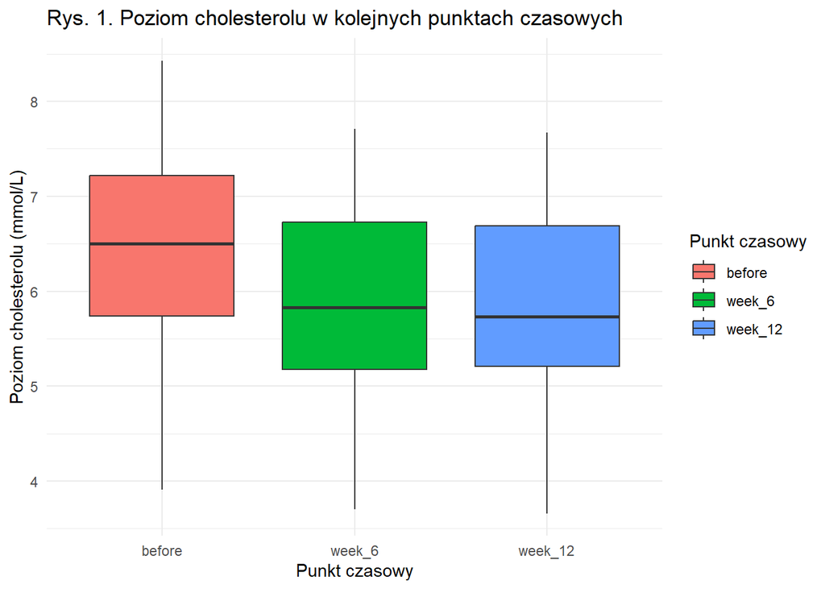

Na podstawie powyższej wizualizacji można stwierdzić brak występowania wartości odstających w przypadku każdego z poziomów czynnika wewnątrzgrupowego.

### 3.2. Weryfikacja założeń

W celu prawidłowego przeprowadzenia analizy wariancji z powtarzanymi pomiarami, kluczowe jest upewnienie się, że spełnione zostały odpowiednie założenia. Dla rozważanych testów statystycznych przyjęto poziom istotności **$\alpha$ = 5%**.

#### 3.2.1. Normalność rozkładu

W celu zbadania normalności rozkładu zmiennej zależnej przy każdym z poziomów czynnika wewnątrzgrupowego przeprowadzono test Shapiro-Wilka. Układ hipotez dla wspomnianego testu jest następujący:

$$\begin{align*}
\small{H}_0: & \small \text { dane mają rozkład normalny} \\
\small{H}_1: & \small \text{ dane nie mają rozkładu normalnego}
\end{align*}$$

```r
shapiro_t <- cholesterol_data %>%
  group_by(time) %>%
  shapiro_test(cholesterol) %>%
  ungroup()
print(shapiro_t)
```

```
## # A tibble: 3 × 4
##   time    variable    statistic     p
##   <fct>   <chr>           <dbl> <dbl>
## 1 before  cholesterol     0.982 0.967
## 2 week_6  cholesterol     0.977 0.912
## 3 week_12 cholesterol     0.977 0.918
```

Na poziomie istotności 0.05 nie ma podstaw do odrzucenia hipotezy zerowej dla żadnego z poziomów. Oznacza to, że rozkład zmiennej zależnej w ramach każdego poziomu czynnika wewnątrzgrupowego jest zgodny z rozkładem normalnym.

#### 3.2.2. Sferyczność danych

Kolejnym krokiem jest sprawdzenie założenia o sferyczności danych. Inaczej mówiąc należy zweryfikować hipotezę o równości wariancji różnic wśród wszystkich możliwych par eksperymentalnych. Dla trzech powtarzanych pomiarów hipotezy badawcze przyjmują postać:

$$\begin{align*}
\small{H}_0: & \small \quad
\sigma_{1-2}^2=\sigma_{1-3}^2=\sigma_{2-3}^2 \\
\small{H}_1: & \small \quad \sigma_{1-2}^2 \neq \sigma_{1-3}^2 \neq
\sigma_{2-3}^2
\end{align*}$$

W celu oceny założenia o sferyczności obliczono różnice między wartościami dla wszystkich możliwych par poziomów czynnika powtarzanych pomiarów. Następnie dla uzyskanych różnic wyznaczono wariancje. Wartości wariancji dla poszczególnych różnic przedstawia poniższa tabela.

Tabela 2. Wariancje dla różnic między parami poziomów czynnika

| Różnica | Wariancja |
| --- | --- |
| Before - Week 6 | 0.024 |
| Before - Week 12 | 0.032 |
| Week 6 - Week 12 | 0.005 |

Na podstawie analizy wyników zamieszczonych w tabeli 2 można stwierdzić, że wariancja dla różnicy *Week 6 - Week 12* jest znacznie mniejsze niż wariancje dla różnic *Before - Week 6* oraz *Before - Week 12*. Uzyskane rezultaty wskazują na możliwość naruszenia założenia o sferyczności danych. Celem formalnej oceny występowania istotnego zróżnicowania między wariancjami różnic zostanie przeprowadzony test sferyczności Mauchly’ego. Wspomniany test jest wyznaczany automatycznie przy przeprowadzaniu testu ANOVA.

```r
repeated_anova <- anova_test(data = cholesterol_data, dv = cholesterol, wid = id, within = time)
repeated_anova[2]
```

```
## $`Mauchly's Test for Sphericity`
##   Effect     W        p p<.05
## 1   time 0.381 0.000444     *
```

Uzyskana wartość p w teście Mauchly’ego jest znacznie mniejsza od przyjętego poziomu istotności 0.05, co wskazuje na odrzucenie hipotezy zerowej. Oznacza to, że wariancje różnic między pomiarami nie są równe, co potwierdza wcześniejsze przypuszczenia.

W przypadku niespełnienia założenia sferyczności zamiast testu F należy skorzystać z wariantu skorygowanego: korekty Greenhouse’a-Geisera lub korekty Huynha-Feldta. Korekty nie wpływają na zmianę wartości statystyki, natomiast powodują zmianę liczby stopni swobody.

### 3.3 ANOVA z powtarzanymi pomiarami

Przeprowadzono jednoczynnikową analizę wariancji z powtarzanymi pomiarami w modelu jednozmiennowym z uwzględnieniem korekty Greenhouse’a-Geisera. W ramach analizy weryfikowano hipotezy:

$$\begin{align*}
\small H_0: m_{1} = m_{A2} = \ldots = m_{k} \hspace{5.5em}
\small H_1: m_{i} \neq m_{j} \hspace{1.5em} dla \ pewnych \ \ \ i \neq
j \\
\end{align*}$$

```r
print(get_anova_table(repeated_anova))
```

```
## ANOVA Table (type III tests)
##
##   Effect  DFn DFd       F        p p<.05   ges
## 1   time 1.24  21 212.321 3.89e-13     * 0.061
```

Mimo uwzględnienia korekty Greenhouse’a-Geisera, uzyskane wartości p są znacząco mniejsze niż poziom istotności 0.05, zatem hipoteza zerowa zostaje odrzucona. Oznacza to, że wyniki całkowitego cholesterolu uzyskane w poszczególnych pomiarach istotnie różniły się od siebie.

### 3.4. Analiza post-hoc

W przypadku odrzucenia hipotezy zerowej w jednoczynnikowej analizie wariancji dla powtarzanych pomiarów, konieczne jest przeprowadzenie testu post-hoc, aby zidentyfikować, między którymi punktami czasowymi podczas stosowania diety wystąpiły istotne statystycznie różnice w otrzymanych wynikach pomiarów całkowitego cholesterolu. W tym celu zastosowano test Bonferroniego, który bardzo dobrze sprawdza się przy niewielkiej liczbie porównań. Należy jednak pamiętać, że wprowadzanie poprawek na liczbę wykonywanych porównań wpływa na zmianę poziomu istotności. Dla analizowanego przypadku poziom istotności wynosi wówczas w przybliżeniu 0.017.

$$\begin{align*}
\small H_0: m_{i} = m_{j} \hspace{3.5em} dla \ \ i \neq j \\
\small H_1: m_{i} \neq m_{j} \hspace{3.5em} dla \ \ i \neq j \\
\end{align*}$$

```r
post_hoc_results <- cholesterol_data %>%
  pairwise_t_test(cholesterol ~ time,
                  paired = TRUE,
                  p.adjust.method = "bonferroni")
options(width = 200)
print(post_hoc_results)
```

```
## # A tibble: 3 × 10
##   .y.         group1 group2     n1    n2 statistic    df        p    p.adj p.adj.signif
## * <chr>       <chr>  <chr>   <int> <int>     <dbl> <dbl>    <dbl>    <dbl> <chr>
## 1 cholesterol before week_6     18    18     15.4     17 1.96e-11 5.88e-11 ****
## 2 cholesterol before week_12    18    18     14.9     17 3.28e-11 9.84e-11 ****
## 3 cholesterol week_6 week_12    18    18      3.78    17 1   e- 3 4   e- 3 **
```

Na podstawie powyższych wyników można zauważyć, że wszystkie wartości p są znacznie mniejsze niż 0.017 dla każdej z badanych par punktów czasowych stosowania diety. W związku z powyższym należy odrzucić hipotezę zerową na rzecz hipotezy alternatywnej. Oznacza to, że występują statystycznie istotne różnice w wynikach pomiarów całkowitego cholesterolu w poszczególnych punktach czasowych stosowania diety.

Dla uzyskanych wyników analizy post-hoc opracowano wizualizację, która umożliwia precyzyjną ocenę zmian poziomu całkowitego cholesterolu w czasie oraz określenie kierunku tych zmian. Wykorzystano w tym celu wykresy pudełkowe, uzupełnione o punkty reprezentujące średnie wartości poziomu całkowitego cholesterolu dla poszczególnych punktów czasowych. Ponadto, na wykresie uwzględniono linię łączącą te punkty, by ułatwić interpretację trendu zmian poziomu cholesterolu w analizowanym okresie.

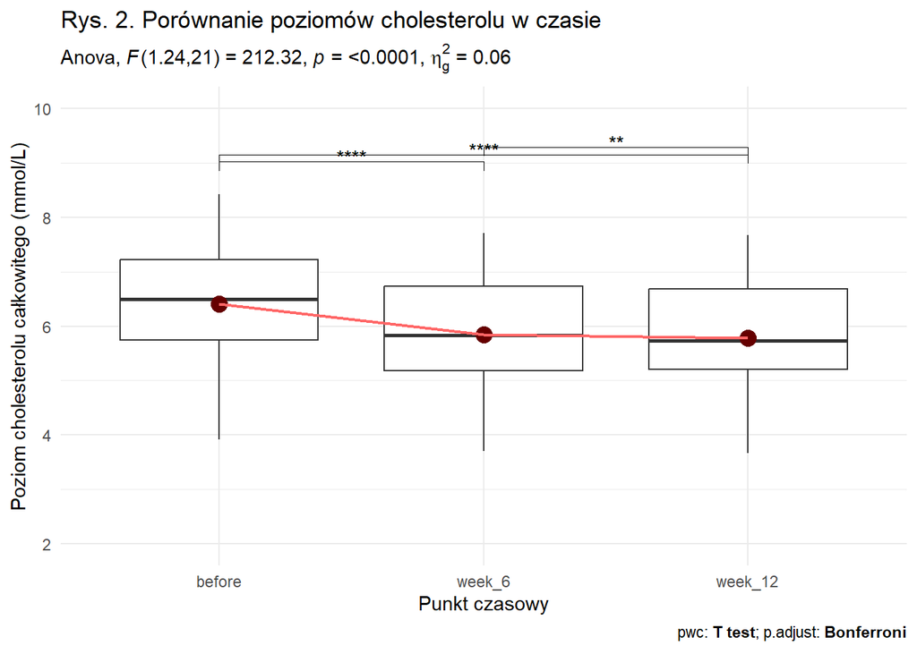

Przedstawiona wizualizacja potwierdza, że wprowadzenie odpowiedniej diety ma statystycznie istotny wpływ na poziom całkowitego cholesterolu. Dodatkowo, zauważalna jest tendencja spadkowa poziomu cholesterolu w kolejnych punktów czasowych, co sugeruje korzysty wpływ zmian w diecie na wyniki pomiarów.

### 3.5. Podsumowanie

Przeprowadzona analiza statystyczna wykazała istotne różnice w poziomie całkowitego cholesterolu we krwi w kolejnych punktach czasowych po wprowadzeniu diety. Porównania parami, uwzględniające poprawkę Bonferroniego, ujawniły, że z każdym kolejnym pomiarem poziom całkowitego cholesterolu u pacjentów ulegał stopniowemu obniżeniu.

Te rezultaty sugerują, że zmiana w diecie polegająca na zastąpieniu masła margaryną, może prowadzić do stopniowego obniżenia poziomu cholesterolu. Jest to zgodne z wcześniejszymi badaniami, które wskazują na korzyści zdrowotne wynikające z zamiany tłuszczów nasyconych obecnych w maśle na tłuszcze nienasycone zawarte w margarynie.

## 4. ANCOVA

**Analiza kowariancji (ANCOVA)** umożliwia zbadanie wpływu jednego lub więcej czynników na zmienną zależną, przy jednoczesnym kontrolowaniu wpływu zmiennej towarzyszącej. W niniejszym badaniu wykorzystano zestaw danych zawierający pomiary poziomu stresu u 45 pacjentów, którzy uczestniczyli w 6-tygodniowym programie treningowym, realizowanym na trzech różnych poziomach intensywności: niskim, umiarkowanym oraz wysokim. Celem analizy jest określenie, czy intensywność wykonywanych ćwiczeń ma istotny wpływ na zmniejszenie poziomu stresu. Ponadto oczekuje się, że redukcja poziomu stresu będzie również zależała od jego wartości początkowej, zmierzonej przed rozpoczęciem programu.

Charakterystyka zmiennych:

- **`post_test`**: pomiar poziomu stresu dokonany po 6-tygodniowym programie treningowym
- **`exercise_intensity`**: poziom intensywności wykonywanych ćwiczeń w ramach programu treningowego, przyjmuje trzy poziomy:
  - `low` - program treningowy z ćwiczeniami o niskiej intensywności
  - `moderate` - program treningowy z ćwiczeniami o umiarkowanej intensywności
  - `high` - program treningowy z ćwiczeniami o wysokiej intensywności
- **`pre_test`**: pomiar poziomu stresu dokonany przed rozpoczęciem programu treningowego

| exercise_intensity | post_test | pre_test |
| --- | --- | --- |
| high | 13.1 | 14.1 |
| high | 13.9 | 14.5 |
| high | 14.3 | 15.7 |
| high | 15.2 | 16.0 |
| high | 16.0 | 16.5 |
| high | 16.3 | 16.9 |
| high | 17.1 | 17.0 |
| high | 16.5 | 17.0 |
| high | 17.0 | 17.3 |
| high | 16.3 | 17.3 |
| high | 16.8 | 17.8 |
| high | 17.7 | 17.9 |
| high | 18.1 | 19.1 |
| high | 18.7 | 19.4 |
| high | 19.1 | 19.8 |
| moderate | 12.6 | 13.7 |
| moderate | 14.0 | 14.7 |
| moderate | 14.3 | 14.9 |
| moderate | 15.1 | 15.1 |
| moderate | 14.8 | 15.8 |
| moderate | 16.0 | 16.4 |
| moderate | 15.7 | 16.6 |
| moderate | 17.2 | 16.9 |
| moderate | 16.0 | 16.9 |
| moderate | 16.8 | 17.2 |
| moderate | 16.6 | 17.8 |
| moderate | 17.9 | 17.8 |
| moderate | 17.3 | 18.2 |
| moderate | 17.9 | 18.4 |
| moderate | 18.6 | 19.3 |
| low | 14.2 | 14.6 |
| low | 15.1 | 15.0 |
| low | 15.4 | 15.5 |
| low | 15.9 | 15.7 |
| low | 16.7 | 16.4 |
| low | 17.2 | 16.9 |
| low | 16.3 | 17.1 |
| low | 16.8 | 17.3 |
| low | 17.0 | 17.5 |
| low | 17.7 | 17.6 |
| low | 17.4 | 17.8 |
| low | 17.9 | 17.9 |
| low | 18.1 | 18.4 |
| low | 18.5 | 18.5 |
| low | 18.8 | 19.0 |

### 4.1. Wstępna analiza danych

Przed przystąpieniem do głównej części analizy zbadano strukturę rozważanych danych oraz występowanie potencjalnych wartości brakujących. W przypadku stwierdzenia wystąpienia nieprawidłowości wprowadzono stosowne modyfikacje. Następnie wygenerowano wykresy pudełkowe, które posłużyły do oceny obecności obserwacji odstających w zbiorze danych. Wspomniane wizualizacje zostały zamieszczone poniżej.

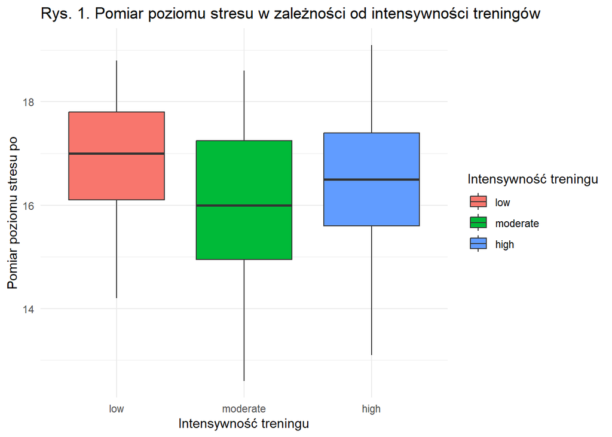

Na podstawie powyższej wizualizacji można stwierdzić, iż w przypadku czynnika określającego intensywność ćwiczeń realizowanych w ramach programu treningowego nie obserwuje się występowania wartości odstających. Poniżej zamieszczono statystyki opisowe wyników poziomu stresu przed i po realizowaniu programu treningowego w podziale na grupy określone intensywnością wykonywanych ćwiczeń.

Tabela 1. Statystyki opisowe badanych zmiennych w podziale na grupy

| Intensywność treningu | Liczebność | Pomiar stresu przed Średnia | Pomiar stresu przed Odchylenie standardowe | Pomiar stresu po Średnia | Pomiar stresu po Odchylenie standardowe |
| --- | --- | --- | --- | --- | --- |
| low | 15 | 17.013 | 1.321 | 16.867 | 1.303 |
| moderate | 15 | 16.647 | 1.566 | 16.053 | 1.666 |
| high | 15 | 17.087 | 1.629 | 16.407 | 1.719 |

Na podstawie wartości średnich arytmetycznych przedstawionych w tabeli 1 można przypuszczać, że intensywność treningu nie ma wpływu na zmniejszenie poziomu stresu. Uczestnicy badania, którzy realizowali program treningowy z ćwiczeniami o umiarkowanej intensywności, osiągnęli nieznacznie niższe wyniki pomiarów poziomu stresu po jego zakończeniu w porównaniu do innych intensywności ćiwczeń. Jednakże, biorąc pod uwagę różnice między pomiarem stresu przed i po uczestnictwie w programie treningowym, największa różnica odnotowana została w grupie uczestników wykonujących treningi charakteryzujące się wysoką intensywnością.

### 4.2. Weryfikacja założeń

W celu prawidłowego przeprowadzenia analizy kowariancji, kluczowe jest upewnienie się, że spełnione zostały odpowiednie założenia. Dla rozważanych testów statystycznych przyjęto poziom istotności **$\alpha$ = 5%**.

#### 4.2.1. Normalność w grupach

W celu zbadania normalności rozkładu zmiennej zależnej w porównywanych grupach uczestników przeprowadzono test Shapiro-Wilka. Głównym atutem tego testu jest jego duża moc w przypadku prób o małej liczności. Układ hipotez dla wspomnianego testu jest następujący:

$$\begin{align*}
\small{H}_0: & \small \text { dane mają rozkład normalny} \\
\small{H}_1: & \small \text{ dane nie mają rozkładu normalnego}
\end{align*}$$

```
## # A tibble: 3 × 4
##   exercise_intensity variable  statistic     p
##   <fct>              <chr>         <dbl> <dbl>
## 1 low                post_test     0.973 0.906
## 2 moderate           post_test     0.975 0.920
## 3 high               post_test     0.968 0.826
```

Wyniki testu Shapiro-Wilka wskazują na brak podstaw do odrzucenia hipotezy zerowej. Oznacza to, że na poziomie istotności 0.05, dane w obrębie każdej grupy mają rozkład normalny.

#### 4.2.2. Jednorodność wariancji w grupach

Kolejnym krokiem jest weryfikacja założenia o jednorodności wariancji w grupach. W tym celu zdecydowano się na zastosowanie testu Bartletta. Jednym z istotnych ograniczeń wspomnianego testu jest jego wrażliwość na odstępstwa od normalności rozkładu danych. W kontekście analizowanych danych, założenie o normalności zostało formalnie zweryfikowane przy pomocy testu Shapiro - Wilka, co umożliwia bezproblemowe zastosowanie tego testu w niniejszym przypadku.

$$\begin{align*}
\small{H}_0: & \small \quad \sigma_{1}^2=\sigma_{2}^2= \ ...\
=\sigma_{k}^2 \\
\small{H}_1: & \small \quad \sigma_{i}^2 \neq \sigma_{j}^2
\hspace{1.5em} dla \ pewnych \ \ \ i \neq j \\
\end{align*}$$

```
##
##  Bartlett test of homogeneity of variances
##
## data:  post_test by exercise_intensity
## Bartlett's K-squared = 1.1702, df = 2, p-value = 0.557
```

Dla ustalonego poziomu istotności $\alpha$, nie ma podstaw do odrzucenia hipotezy zerowej. Oznacza to, że założenie o jednorodności wariancji w grupach jest spełnione.

### 4.3. Jednoczynnikowa analiza wariancji

Pozytywna weryfikacja założeń niezbednych do przeprowadzenia jednoczynnikowej analizy wariancji pozwoliła na sprawdzenie, czy wyniki pomiarów poziomu stresu po zakończeniu programu treningowego różniły się w zależności od stopnia intensywności ćwiczeń.

```r
anova_model <- aov(post_test ~ exercise_intensity, data = stress_score)
summary(anova_model)
```

```
##                    Df Sum Sq Mean Sq F value Pr(>F)
## exercise_intensity  2   4.99   2.495   1.008  0.374
## Residuals          42 103.98   2.476
```

Wartość p dla zmiennej `exercise_intensity` jest większa od ustalonego poziomu istotności, co wskazuje, że intensywność treningu nie wykazuje statystycznie istotnego wpływu na poziom stresu.

### 4.4. Weryfikacja założeń ANCOVY

W celu weryfikacji przypuszczenia, że na końcowy wynik poziomu stresu może mieć wpływ pomiar stresu dokonany przed rozpoczęciem programu treningowego przeprowadzono test analizy kowariancji, gdzie wyjściowy poziom stresu badanych potraktowano jako zmienna towarzysząca. By móc przeprowadzić wspomnianą analizę konieczne jest sprawdzenie dodatkowych założeń. Dla rozważanych testów statystycznych przyjęto poziom istotności **$\alpha$ = 5%**.

#### 4.4.1. Liniowość

Jednym z założeń pozwalających na przeprowadzenie analizy kowariancji jest wystepowanie istotnej korelacji pomiędzy zmienną towarzyszącą a zmienną zależną. Wykres punktowy przedstawiający zależność między zmiennymi z uwzględnieniem podziału na grupy zaprezentowano poniżej.

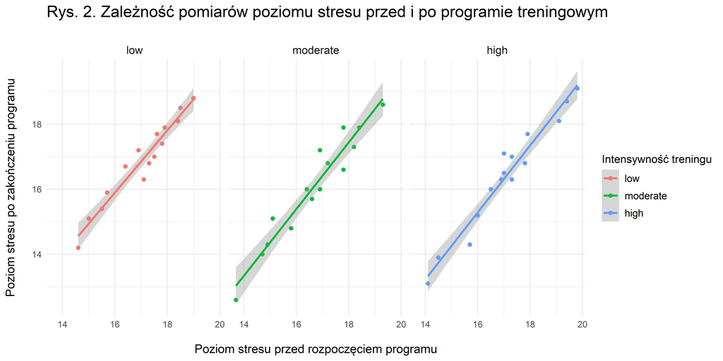

Na podstawie powyższej wizualizacji można stwierdzić występowanie liniowej zależności dla pomiarów poziomu stresu przed i po realizacji programu treningowego w przypadku każdej grupy. W celu formalnego potwierdzenia skorelowania zmiennych `pre_test` oraz `post_test` przeprowadzono test korelacji Pearsona, którego wyniki przedstawiono poniżej.

```
## # A tibble: 3 × 3
##   exercise_intensity correlation  p_value
##   <fct>                    <dbl>    <dbl>
## 1 low                      0.969 3.08e- 9
## 2 moderate                 0.963 8.18e- 9
## 3 high                     0.976 5.68e-10
```

Uzyskane wyniki potwierdziły istotne skorelowanie pomiarów poziomu stresu przed realizacją programu treningowego z pomiarami dokonanymi po jego zakończeniu. Oznacza to możliwość zaburzenia rzeczywistego wpływu intensywności ćwiczeń na redukcję stresu, potwierdzając tym samym słuszność zastosowania ANCOVY.

#### 4.4.2. Korelacja zmiennych niezależnych

W ramach kolejnego etapu analizy sprawdzono, czy pomiary poziomu stresu uzyskane przed rozpoczęciem programu treningowego (zmienna współwystępująca `pre_test`) są niezależne od intensywności ćwiczeń (czynnika grupującego `exercise_intensity`). W tym celu przeprowadzono jednoczynnikową analizę wariancji. Przed przeprowadzeniem ANOVY zweryfikowano spełnienie odpowiednich założeń: normalności rozkładu badanej zmiennej w porównywanych grupach oraz równości wariancji w grupach. Wyniki tej analizy zaprezentowano poniżej.

```r
pre_norm <- stress_score %>%
  group_by(exercise_intensity) %>%
  shapiro_test(pre_test)  %>%
  ungroup()
```

```
## # A tibble: 3 × 4
##   exercise_intensity variable statistic     p
##   <fct>              <chr>        <dbl> <dbl>
## 1 low                pre_test     0.954 0.588
## 2 moderate           pre_test     0.977 0.949
## 3 high               pre_test     0.964 0.769
```

```r
bartlett.test(pre_test ~ exercise_intensity, data = stress_score)
```

```
##
##  Bartlett test of homogeneity of variances
##
## data:  pre_test by exercise_intensity
## Bartlett's K-squared = 0.6438, df = 2, p-value = 0.7248
```

Wyniki testu Shapiro-Wilka wskazują na brak podstaw do kwestionowania założenia normalności rozkładu. Podobny wniosek można wyciągnąć w przypadku oceny równości wariancji na podstawie wyników testu Bartletta. Pozytywna weryfikacja założeń pozwala na przeprowadzenie analizy wariancji.

```r
model_cov <- aov(pre_test ~ exercise_intensity, data = stress_score)
summary(model_cov)
```

```
##                    Df Sum Sq Mean Sq F value Pr(>F)
## exercise_intensity  2   1.67  0.8336   0.365  0.696
## Residuals          42  95.89  2.2831
```

Na podstawie otrzymanych wyników można stwierdzić, że pomiary poziomu stresu pomiędzy badanymi grupami uczestników programu przed ropoczęciem treningów były statystycznie nieistotne. Oznacza to, że wyniki pomiarów poziomu stresu przed rozpoczęciem programu ćwiczeń nie różniły się w sposób znaczący między uczestnikami poszczególnych grup treningowych.

#### 4.4.3. Normalność rozkładu reszt

Do sprawdzenia założenia o normalności rozkładu reszt modelu regresji zastosowano test Shapiro-Wilka. Hipotezy dla testu normalności rozkładu reszt mają postać:

$$\begin{align*}
\small{H}_0: & \small \text { reszty mają rozkład normalny} \\
\small{H}_1: & \small \text{ reszty nie mają rozkładu normalnego}
\end{align*}$$

```r
model <- lm(data = stress_score, post_test ~ pre_test + exercise_intensity)
shapiro.test(model$residuals)
```

```
##
##  Shapiro-Wilk normality test
##
## data:  model$residuals
## W = 0.97796, p-value = 0.5395
```

Uzyskana wartość p wynosi 0,5395. Jako, że jest ona większa od przyjętego poziomu istotności nie ma podstaw do odrzucenia hipotezy zerowej. Oznacza to, że reszty modelu mają rozkład normalny.

#### 4.4.4. Homoskedastyczność reszt

ANCOVA zakłada, że wariancja reszt modelu regresji powinna być stała dla wszystkich poziomów zmiennej niezależnej. Jeżeli wspomniane założenie nie jest spełnione mamy do czynienia z tzw. heteroskedastycznością. Jednym z testów pozwalających na weryfikację hipotezy dotyczącej jednorodności wariancji reszt jest test Breuscha-Pagana.

$$\begin{align*}
\small{H}_0: & \small \quad \sigma_{1}^2=\sigma_{2}^2= \ ...\
=\sigma_{k}^2 \\
\small{H}_1: & \small \quad \sigma_{i}^2 \neq \sigma_{j}^2
\hspace{1.5em} dla \ pewnych \ \ \ i \neq j \\
\end{align*}$$

```r
model <- lm(data = stress_score, post_test ~ pre_test + exercise_intensity)
bptest(model)
```

```
##
##  studentized Breusch-Pagan test
##
## data:  model
## BP = 1.9124, df = 3, p-value = 0.5908
```

Uzyskana wartość p wynosi 0.5908. Jest ona większa od przyjętego poziomu istotności α = 0.05 zatem nie ma podstaw do odrzucenia hipotezy zerowej $\small {H_0}$. Oznacza to, że w estymowanym modelu nie występuje heteroskedastyczność, czyli reszty charakteryzuje jednorodność wariancji.

#### 4.4.5. Równoległość regresji w obrębie grup

W następnym kroku sprawdzono założenie analizy kowariancji dotyczące równoległości regresji w obrębie grup tj. występowania istotnej statystycznie interakcji pomiędzy czynnikiem a zmienną towarzyszącą. Weryfikacji występowania wspomnianej zależności dokonano przeprowadzając analizę wariancji.

$$\small{H}_0: \beta_3 = 0 \\
\small{H}_1: \beta_3 \neq 0$$
gdzie $\small \beta_3$ to parametr przy zmiennej interakcji.

```r
interact_aov <- stress_score %>% anova_test(post_test ~ exercise_intensity*pre_test)
print(interact_aov)
```

```
## ANOVA Table (type II tests)
##
##                        Effect DFn DFd       F        p p<.05   ges
## 1          exercise_intensity   2  39   7.665 2.00e-03     * 0.282
## 2                    pre_test   1  39 611.599 1.92e-25     * 0.940
## 3 exercise_intensity:pre_test   2  39   0.298 7.44e-01       0.015
```

Na podstawie otrzymanych wyników można stwierdzić, że zależność wyników pomiaru stresu przed rozpoczęciem programu treningowego od wyników pomiaru poziomu stresu po jego zakończeniu kształtuje się podobnie we wszystkich trzech porównywanych grupach uczestników. Oznacza to, że odpowiednie teoretyczne linie regresji przebiegają w przybliżeniu równolegle do siebie. Ilustruje to pokazany niżej wykres.

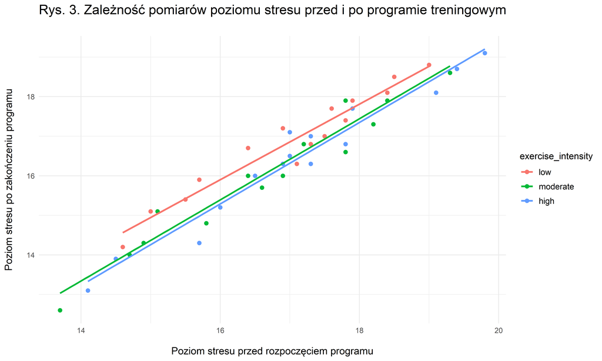

### 4.5. ANCOVA

Pozytywna weryfikacja założeń ANCOVA umożliwia sprawdzenie, czy po uwzględnieniu poziomu stresu przed rozpoczęciem programu wystąpiło istotne statystycznie zróżnicowanie przeciętnego poziomu stresu po ukończeniu treningów pomiędzy uczestnikami trzech grup różniących się stopniem intensywności. Poniżej przedstawiono wyniki właściwej analizy kowariancji:

```
## ANOVA Table (type II tests)
##
##               Effect DFn DFd       F       p p<.05   ges
## 1           pre_test   1  41 633.275 1.5e-26     * 0.939
## 2 exercise_intensity   2  41   7.936 1.0e-03     * 0.279
```

Powyższe wyniki wskazują, że wniosek wyciągnięty na podstawie wstępnej analizy danych okazał się błędny. Po uwzględnieniu wyjściowego poziomu stresu wystąpiło istotne zróżnicowanie pomiędzy średnimi wynikami poziomu stresu w porównywanych grupach. Wyznaczone wartości uogólnionej $\eta^2$ wskazują, na silne efekty dla zmiennych `pre_test` oraz `exercise_intensity`. Wielkość efektu dla początkowych pomiarów stresu wyjaśnia 93.9% wariancji w wynikach zmiennej zależniej (`post_test`), co oznacza, że ma bardzo znaczący wpływ na poziom lęku po zakończeniu programu treningowego.

### 4.6. Analiza post-hoc

W celu zidentyfikowania, które grupy różnią się między sobą przeprowadzono analizę post-hoc z korektą Bonferroniego. Wyniki przeprowadzonych porównań zaprezentowano poniżej.

```
## # A tibble: 3 × 8
##   .y.       group1   group2      df statistic        p   p.adj p.adj.signif
##   <chr>     <chr>    <chr>    <dbl>     <dbl>    <dbl>   <dbl> <chr>
## 1 post_test low      moderate    41     3.08  0.00373  0.0112  *
## 2 post_test low      high        41     3.72  0.000592 0.00178 **
## 3 post_test moderate high        41     0.628 0.534    1       ns
```

Wyniki przeprowadzonej analizy wskazują, że po uwzględnieniu pomiarów poziomu stresu u badanych przed rozpoczęciem ćwiczeń, widoczne jest występowanie statystycznie istotnych różnic pod względem końcowego wyniku poziomu stresu między uczestnikami grup o niskiej i umiarkowanej intensywności treningu oraz między grupami o niskiej i wysokiej intensywności. Jedynie w przypadku porównania grup wykonujących ćwiczenia o umiarkowanym oraz wysokim stopniu trudności nie stwierdzono statystycznie istotnej różnicy.

Na kolejnym wydruku zamieszczono średnie przeliczone na jednakową wartość średnią wyjściowego pomiaru stresu wraz z błędami standardowymi oraz odpowiednimi przedziałami ufności. Poniżej zamieszczono również stosowną wizualizację.

```
## # A tibble: 3 × 8
##   pre_test exercise_intensity emmean    se    df conf.low conf.high method
##      <dbl> <fct>               <dbl> <dbl> <dbl>    <dbl>     <dbl> <chr>
## 1     16.9 low                  16.8 0.101    41     16.6      17.0 Emmeans test
## 2     16.9 moderate             16.3 0.102    41     16.1      16.5 Emmeans test
## 3     16.9 high                 16.2 0.102    41     16.0      16.4 Emmeans test
```

Najniższy średni wynik poziomu stresu zaobserwowano w przypadku grupy wykonującej ćwiczenia o wysokiej intensywności, co sugeruje, że wyższa intensywność ćwiczeń może być bardziej efektywna w przypadku redukcji stresu. To przypuszczenie potwierdza poniższa wizualizacja.

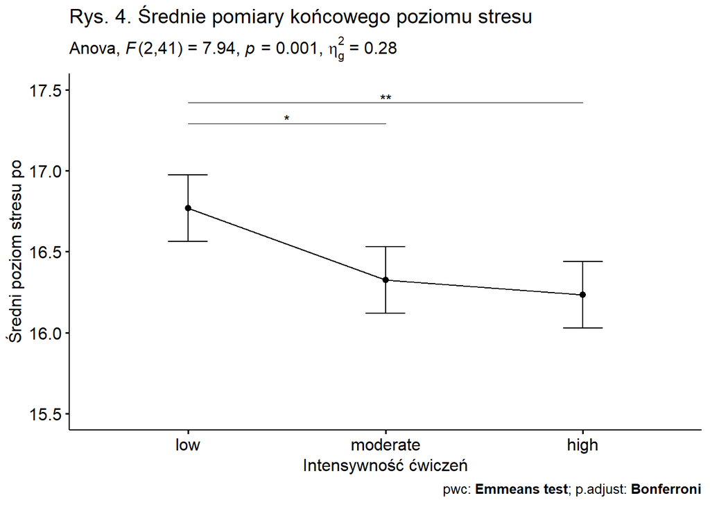

Poniżej zamieszczono podsumowujące porównanie końcowych pomiarów stresu z uwzględnieniem wyjściowego poziomu stresu uczestników w formie tabelarycznej potwierdzające wpływ zmiennej towarzyszącej na wyniki przeprowadzonego badania. Warto zwrócić uwagę na znaczne zmniejszenie uzyskiwanych błędów dla średnich.

Tabela 2. Porównanie średnich i błędów standardowych pomiarów stresu z i bez uwzględnienia zmiennej towarzyszącej

| Intensywność ćwiczeń | Pomiar przed Średnia | Pomiar przed Błąd standardowy | Pomiar po (bez kowarianty) Średnia | Pomiar po (bez kowarianty) Błąd standardowy | Pomiar po (z kowariantą) Średnia | Pomiar po (z kowariantą) Błąd standardowy |
| --- | --- | --- | --- | --- | --- | --- |
| low | 17.013 | 0.341 | 16.867 | 0.336 | 16.768 | 0.101 |
| moderate | 16.647 | 0.404 | 16.053 | 0.430 | 16.325 | 0.102 |
| high | 17.087 | 0.421 | 16.407 | 0.444 | 16.234 | 0.102 |

### 4.7. Podsumowanie

Jednoczynnikową analizę kowariancji przeprowadzono w celu oceny wpływu programów treningowych o różnej intensywności ćwiczeń na redukcję stresu u uczestników, jednocześnie biorąc pod uwagę początkowy poziom stresu badanych. Po uwzględnieniu pomiarów stresu wykonanych przed rozpoczęciem programu zaobserwowano statystycznie istotne różnice w wynikach poziomu stresu po zakończeniu treningów dla większości grup.

Wyniki przeprowadzonej analizy wskazują na istotne znaczenie aktywności fizycznej w redukcji stresu, jednocześnie podkreślając, że intensywność wykonywanych ćwiczeń stanowi kluczowy element wpływający na ich efektywność. Regularne treningi o wysokiej intensywności mogą znacząco zredukować poziom stresu, a w konsekwencji przyczynić się do poprawy zdrowia psychicznego.